# EDA - Exploratory Data Analysis

#### Version: 1.00 - April 3rd, 2020

#### 1. Load Data

#### 2. Worldwide Trend

#### 3. Country-wise growth

#### 4. Looking at provinces

#### 5. Zoom into USA

#### 6. Europe

#### 7. Asia

#### 8. Which countries are recovering now?

#### 9. When will this converge - estimation by sigmoid fitting

```python
import gc
import os
from pathlib import Path
import random
import sys

from tqdm.notebook import tqdm
import numpy as np
import pandas as pd
import scipy as sp


import matplotlib.pyplot as plt
import seaborn as sns

from IPython.core.display import display, HTML

# --- plotly ---
from plotly import tools, subplots
import plotly.offline as py
py.init_notebook_mode(connected=True)
import plotly.graph_objs as go
import plotly.express as px
import plotly.figure_factory as ff
import plotly.io as pio
pio.templates.default = "plotly_dark"

# --- models ---
from sklearn import preprocessing
from sklearn.model_selection import KFold
import lightgbm as lgb
import xgboost as xgb
import catboost as cb

# --- setup ---
pd.set_option('max_columns', 50)
```

### Load Data

```python
# Input data files are available in the "../input/" directory.
import os
for dirname, _, filenames in os.walk('./'):
    filenames.sort()
    for filename in filenames:
        print(os.path.join(dirname, filename))
```

[output not shown]

[output cut: 9368 more lines]

[output not shown]

```python
%%time
datadir = Path('./week 3/')

# Read in the data CSV files
train = pd.read_csv(datadir/'train.csv')
test = pd.read_csv(datadir/'test.csv')
submission = pd.read_csv(datadir/'submission.csv')
```

```
Wall time: 32 ms
```

```python
train
```

|  | Id | Province_State | Country_Region | Date | ConfirmedCases | Fatalities |
| --- | --- | --- | --- | --- | --- | --- |
| 0 | 1 | NaN | Afghanistan | 2020-01-22 | 0.0 | 0.0 |
| 1 | 2 | NaN | Afghanistan | 2020-01-23 | 0.0 | 0.0 |
| 2 | 3 | NaN | Afghanistan | 2020-01-24 | 0.0 | 0.0 |
| 3 | 4 | NaN | Afghanistan | 2020-01-25 | 0.0 | 0.0 |
| 4 | 5 | NaN | Afghanistan | 2020-01-26 | 0.0 | 0.0 |
| ... | ... | ... | ... | ... | ... | ... |
| 22027 | 32703 | NaN | Zimbabwe | 2020-03-29 | 7.0 | 1.0 |
| 22028 | 32704 | NaN | Zimbabwe | 2020-03-30 | 7.0 | 1.0 |
| 22029 | 32705 | NaN | Zimbabwe | 2020-03-31 | 8.0 | 1.0 |
| 22030 | 32706 | NaN | Zimbabwe | 2020-04-01 | 8.0 | 1.0 |
| 22031 | 32707 | NaN | Zimbabwe | 2020-04-02 | 9.0 | 1.0 |

22032 rows × 6 columns

```python
test
```

|  | ForecastId | Province_State | Country_Region | Date |
| --- | --- | --- | --- | --- |
| 0 | 1 | NaN | Afghanistan | 2020-03-26 |
| 1 | 2 | NaN | Afghanistan | 2020-03-27 |
| 2 | 3 | NaN | Afghanistan | 2020-03-28 |
| 3 | 4 | NaN | Afghanistan | 2020-03-29 |
| 4 | 5 | NaN | Afghanistan | 2020-03-30 |
| ... | ... | ... | ... | ... |
| 13153 | 13154 | NaN | Zimbabwe | 2020-05-03 |
| 13154 | 13155 | NaN | Zimbabwe | 2020-05-04 |
| 13155 | 13156 | NaN | Zimbabwe | 2020-05-05 |
| 13156 | 13157 | NaN | Zimbabwe | 2020-05-06 |
| 13157 | 13158 | NaN | Zimbabwe | 2020-05-07 |

13158 rows × 4 columns

```python
submission
```

|  | ForecastId | ConfirmedCases | Fatalities |
| --- | --- | --- | --- |
| 0 | 1 | 1 | 1 |
| 1 | 2 | 1 | 1 |
| 2 | 3 | 1 | 1 |
| 3 | 4 | 1 | 1 |
| 4 | 5 | 1 | 1 |
| ... | ... | ... | ... |
| 13153 | 13154 | 1 | 1 |
| 13154 | 13155 | 1 | 1 |
| 13155 | 13156 | 1 | 1 |
| 13156 | 13157 | 1 | 1 |
| 13157 | 13158 | 1 | 1 |

13158 rows × 3 columns

```python
train.rename({'Country_Region': 'country', 'Province_State': 'province', 'Id': 'id', 'Date': 'date', 'ConfirmedCases': 'confirmed', 'Fatalities': 'fatalities'}, axis=1, inplace=True)
test.rename({'Country_Region': 'country', 'Province_State': 'province', 'Id': 'id', 'Date': 'date', 'ConfirmedCases': 'confirmed', 'Fatalities': 'fatalities'}, axis=1, inplace=True)
train['country_province'] = train['country'].fillna('') + '/' + train['province'].fillna('')
test['country_province'] = test['country'].fillna('') + '/' + test['province'].fillna('')
```

## Worldwide Trend

```python
ww_df = train.groupby('date')[['confirmed', 'fatalities']].sum().reset_index()
ww_df['new_case'] = ww_df['confirmed'] - ww_df['confirmed'].shift(1)
ww_df.tail()
```

|  | date | confirmed | fatalities | new_case |
| --- | --- | --- | --- | --- |
| 67 | 2020-03-29 | 719952.0 | 33921.0 | 59411.0 |
| 68 | 2020-03-30 | 782200.0 | 37578.0 | 62248.0 |
| 69 | 2020-03-31 | 857320.0 | 42103.0 | 75120.0 |
| 70 | 2020-04-01 | 932434.0 | 46804.0 | 75114.0 |
| 71 | 2020-04-02 | 1012981.0 | 52978.0 | 80547.0 |

### Watch this exponential growth. It seems to be doubling each week.

```python
fig = px.line(ww_melt_df, x="date", y="value", color='variable',
              title="Worldwide Confirmed/Death Cases Over Time")
fig.show()
```

[interactive chart not shown]

#### The purpose of the log-scale is to see the growth of the growth rate. You see that there is a slight increase of this from the beginning of March to the end of March. Despite the Lockdown policy in the US and Europe, the number is still rapidly increasing.

```python
fig = px.line(ww_melt_df, x="date", y="value", color='variable',
              title="Worldwide Confirmed/Death Cases Over Time (Log scale)",
             log_y=True)
fig.show()
```

[interactive chart not shown]

#### The fatalities curve seems to just be a shift of the curve for confirmed cases, meaning that mortality rate is almost constant. Watch as the mortality rate rises from 3% to 5% as of April 3rd, 2020. Europe and the US has been hit hard.

```python
ww_df['mortality'] = ww_df['fatalities'] / ww_df['confirmed']

fig = px.line(ww_df, x="date", y="mortality",
              title="Worldwide Mortality Rate Over Time")
fig.show()
```

[interactive chart not shown]

## Country-wide Growth

```python
country_df = train.groupby(['date', 'country'])[['confirmed', 'fatalities']].sum().reset_index()
country_df.tail()
```

|  | date | country | confirmed | fatalities |
| --- | --- | --- | --- | --- |
| 12955 | 2020-04-02 | Venezuela | 146.0 | 5.0 |
| 12956 | 2020-04-02 | Vietnam | 233.0 | 0.0 |
| 12957 | 2020-04-02 | West Bank and Gaza | 161.0 | 1.0 |
| 12958 | 2020-04-02 | Zambia | 39.0 | 1.0 |
| 12959 | 2020-04-02 | Zimbabwe | 9.0 | 1.0 |

```python
countries = country_df['country'].unique()
print(f'{len(countries)} countries are in dataset:\n{countries}')
```

```
180 countries are in dataset:
['Afghanistan' 'Albania' 'Algeria' 'Andorra' 'Angola'
 'Antigua and Barbuda' 'Argentina' 'Armenia' 'Australia' 'Austria'
 'Azerbaijan' 'Bahamas' 'Bahrain' 'Bangladesh' 'Barbados' 'Belarus'
 'Belgium' 'Belize' 'Benin' 'Bhutan' 'Bolivia' 'Bosnia and Herzegovina'
 'Botswana' 'Brazil' 'Brunei' 'Bulgaria' 'Burkina Faso' 'Burma' 'Burundi'
 'Cabo Verde' 'Cambodia' 'Cameroon' 'Canada' 'Central African Republic'
 'Chad' 'Chile' 'China' 'Colombia' 'Congo (Brazzaville)'
 'Congo (Kinshasa)' 'Costa Rica' "Cote d'Ivoire" 'Croatia' 'Cuba' 'Cyprus'
 'Czechia' 'Denmark' 'Diamond Princess' 'Djibouti' 'Dominica'
 'Dominican Republic' 'Ecuador' 'Egypt' 'El Salvador' 'Equatorial Guinea'
 'Eritrea' 'Estonia' 'Eswatini' 'Ethiopia' 'Fiji' 'Finland' 'France'
 'Gabon' 'Gambia' 'Georgia' 'Germany' 'Ghana' 'Greece' 'Grenada'
 'Guatemala' 'Guinea' 'Guinea-Bissau' 'Guyana' 'Haiti' 'Holy See'
 'Honduras' 'Hungary' 'Iceland' 'India' 'Indonesia' 'Iran' 'Iraq'
 'Ireland' 'Israel' 'Italy' 'Jamaica' 'Japan' 'Jordan' 'Kazakhstan'
 'Kenya' 'Korea, South' 'Kosovo' 'Kuwait' 'Kyrgyzstan' 'Laos' 'Latvia'
 'Lebanon' 'Liberia' 'Libya' 'Liechtenstein' 'Lithuania' 'Luxembourg'
 'MS Zaandam' 'Madagascar' 'Malaysia' 'Maldives' 'Mali' 'Malta'
 'Mauritania' 'Mauritius' 'Mexico' 'Moldova' 'Monaco' 'Mongolia'
 'Montenegro' 'Morocco' 'Mozambique' 'Namibia' 'Nepal' 'Netherlands'
 'New Zealand' 'Nicaragua' 'Niger' 'Nigeria' 'North Macedonia' 'Norway'
 'Oman' 'Pakistan' 'Panama' 'Papua New Guinea' 'Paraguay' 'Peru'
 'Philippines' 'Poland' 'Portugal' 'Qatar' 'Romania' 'Russia' 'Rwanda'
 'Saint Kitts and Nevis' 'Saint Lucia' 'Saint Vincent and the Grenadines'
 'San Marino' 'Saudi Arabia' 'Senegal' 'Serbia' 'Seychelles'
 'Sierra Leone' 'Singapore' 'Slovakia' 'Slovenia' 'Somalia' 'South Africa'
 'Spain' 'Sri Lanka' 'Sudan' 'Suriname' 'Sweden' 'Switzerland' 'Syria'
 'Taiwan*' 'Tanzania' 'Thailand' 'Timor-Leste' 'Togo'
 'Trinidad and Tobago' 'Tunisia' 'Turkey' 'US' 'Uganda' 'Ukraine'
 'United Arab Emirates' 'United Kingdom' 'Uruguay' 'Uzbekistan'
 'Venezuela' 'Vietnam' 'West Bank and Gaza' 'Zambia' 'Zimbabwe']
```

```python
target_date = country_df['date'].max()

print('Date: ', target_date)
for i in [1, 10, 100, 1000, 10000]:
    n_countries = len(country_df.query('(date == @target_date) & confirmed > @i'))
    print(f'{n_countries} countries have more than {i} confirmed cases')
```

```
Date:  2020-04-02
178 countries have more than 1 confirmed cases
148 countries have more than 10 confirmed cases
112 countries have more than 100 confirmed cases
52 countries have more than 1000 confirmed cases
14 countries have more than 10000 confirmed cases
```

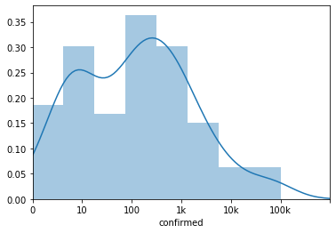

```python
ax = sns.distplot(np.log10(country_df.query('date == "2020-03-27"')['confirmed'] + 1))
ax.set_xlim([0, 6])
ax.set_xticks(np.arange(7))
_ = ax.set_xticklabels(['0', '10', '100', '1k', '10k', '100k'])
```

```python
top_country_df = country_df.query('(date == @target_date) & (confirmed > 1000)').sort_values('confirmed', ascending=False)
top_country_melt_df = pd.melt(top_country_df, id_vars='country', value_vars=['confirmed', 'fatalities'])
```

#### It seems that US, Italy, and Spain top the list with even Germany having more confirmed cases than China. Korea is also high relative to its population. I believe this is because Korea executes inspection aggressively.

```python
fig = px.bar(top_country_melt_df.iloc[::-1],
             x='value', y='country', color='variable', barmode='group',
             title=f'Confirmed Cases/Deaths on {target_date}', text='value', height=1500, orientation='h')
fig.show()
```

[interactive chart not shown]

#### Let's check major country's growth by date.

```python
top30_countries = top_country_df.sort_values('confirmed', ascending=False).iloc[:30]['country'].unique()
top30_countries_df = country_df[country_df['country'].isin(top30_countries)]
fig = px.line(top30_countries_df,
              x='date', y='confirmed', color='country',
              title=f'Confirmed Cases for top 30 country as of {target_date}')
fig.show()
```

[interactive chart not shown]

#### We can see coronavirus hit China first, but its trend has gone down and flattened by March. Europe is hit by the second wave in March (Italy, Spain, Germany, France, UK). The third wave hits the US now, and the US has a higher growth rate than China or Europe. Its main spread starts from the ides of March and its speed is greater than that of Italy.

```python
top30_countries = top_country_df.sort_values('fatalities', ascending=False).iloc[:30]['country'].unique()
top30_countries_df = country_df[country_df['country'].isin(top30_countries)]
fig = px.line(top30_countries_df,
              x='date', y='fatalities', color='country',
              title=f'Fatalities for top 30 country as of {target_date}')
fig.show()
```

[interactive chart not shown]

### We see that in terms of fatalities, Europe is more serious than the US right now

#### Let's look at mortality rate by country

```python
top_country_df = country_df.query('(date == @target_date) & (confirmed > 100)')
top_country_df['mortality_rate'] = top_country_df['fatalities'] / top_country_df['confirmed']
top_country_df = top_country_df.sort_values('mortality_rate', ascending=False)
```

```python
fig = px.bar(top_country_df[:30].iloc[::-1],
             x='mortality_rate', y='country',
             title=f'Mortality rate HIGH: top 30 countries on {target_date}', text='mortality_rate', height=800, orientation='h')
fig.show()
```

[interactive chart not shown]

##### Maybe we can look at countries whose mortality rates are low for insight. THough, many of these countries simply do not report/measure fatalities properly.

```python
fig = px.bar(top_country_df[-30:],
             x='mortality_rate', y='country',
             title=f'Mortality rate LOW: top 30 countries on {target_date}', text='mortality_rate', height=800, orientation='h')
fig.show()
```

[interactive chart not shown]